# IPO Analysis

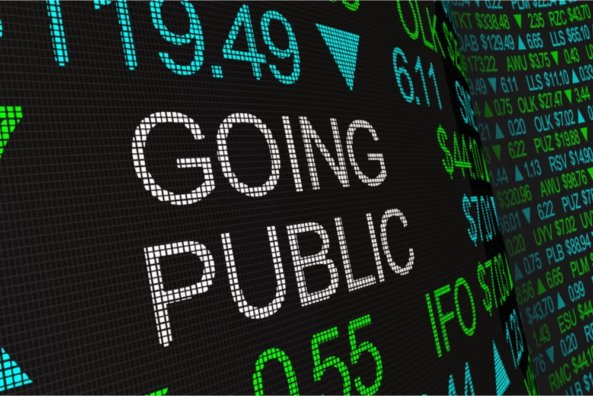

# Introduction

Business and Finance is a dynamic industry that seems to be at the epicenter of anything and everything in our lives. Investment banks (like the JP Morgan’s and Goldman Sach’s of the world) and bankers move capital, in the form of debt or equity, from those who have it to those who need it. And though certain parts of these banks like institutional sales and trading may soon be automized, companies will endlessly continue to merge, acquire, and go public.

So why should we care about all this? Well, think about your favorite company: Facebook, McDonald’s, Nike, Starbucks—at one point or another, they were privately-owned. Somewhere along the way, they became large or successful enough to garner the attention of investors and pulled the trigger on going public.

But what does “going public” entail? A company looking to be publicly listed on the stock market goes through what’s called an Initial Public Offering, or IPO. Companies must first sign off with the Securities and Exchange Commission, the entity that provides the public with transparency on the corporate profitability of U.S. companies. Next, investment banks are hired to market the offering, gauge public stock demand, and set the specific stock price and date of announcement.

If the founders, family, and friends of Starbucks didn’t make the decision to sell bits of its business to the public, it may have never grown exponentially and made available the glorious caramel mocha frappe that millions depend on daily for productivity.

An IPO is surely a big step for a company; it’s the checkpoint that provides greater access to funds (in exchange for parts of the company of course).

## Goal

Through our analysis, we hope to examine certain patterns and consistencies that are apparent with our dataset. We wrangled data included in our csv by certain qualitative factors. For example, we are interested in observing certain business sectors and their patterns. Have some industries been more busy than others since 1996? Analysis like this can be linked with other aspects to piece the puzzle together. Do certain industries have a greater likelihood of going public in certain regions or business sectors? Which states have had the most IPOs since 1996? When is the most common time for a company to go public? From these conclusions we can extrapolate and make broader assumptions.

Broadly, those were our questions of interest. On a finer level, we decided to include a line graph on the various different companies to observe their performance in terms of profitability. Examining a stock’s high and low prices through its recent listings on the public market should provide some useful insight. Namely, is there any telling in what makes a public company successful in the long run?

# Data

Our data comes from two main sources. We first used a CSV from kaggle which included IPOs from the years 1996 to 2018. The kaggle dataset included many different characteristics of each of the IPOs. These characteristics include the number of days the company had a profit, when the company went public, the number of days the IPO exceeded the S&P (A way to measure the success of a stock), and the high and low for the company’s stock for the first 261 days of being public.

Our second source of data comes from Yahoo Finance. We first selected randomly selected 200 IPOs from the original dataset. Then, for those 200 selected IPOs, we webscraped Yahoo Finance to retrieve the high and low stock prices of the stock each day for the past couple months.

Links to the data sources can be found below.

**Links to the Data:**

- [Yahoo Finance](https://finance.yahoo.com)
- [Kaggle Dataset](https://www.kaggle.com/proselotis/financial-ipo-data)

# Analysis

## Map of the Distribution of Location of IPOs

The map below illustrates the how the location of the thousands of IPOs in the dataset is distributed throughout the United States. The most common locations seem to be California, New York, and Texas.

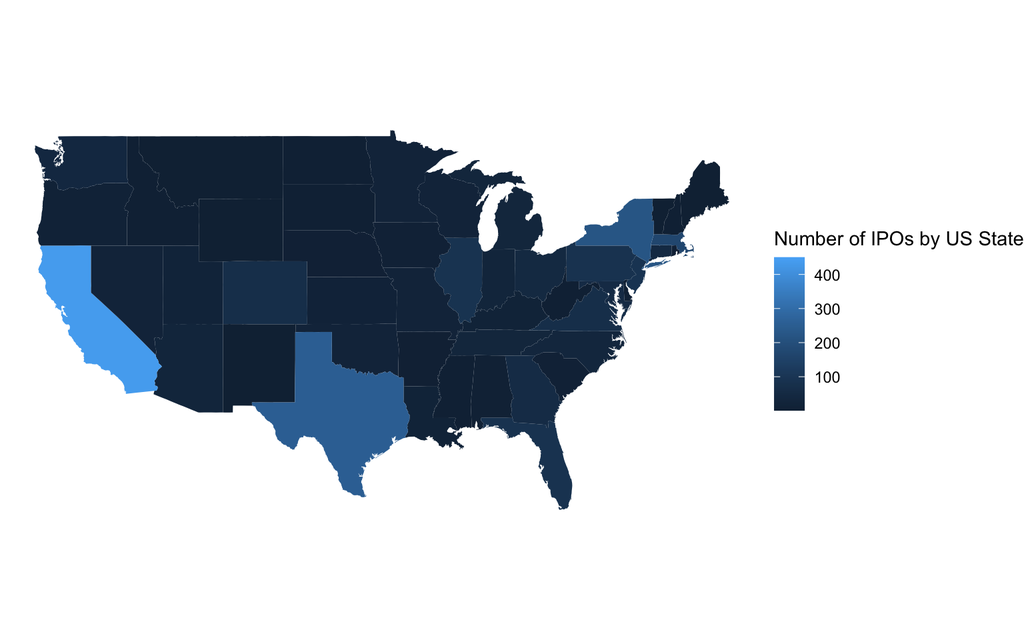

## Shiny App

[interactive chart not shown]

# Conclusion

From our analysis, we concluded that consumer services, finance, healthcare, and technology have been the most active business sectors from 1996 to 2018. Consumer services was a surprising lead, with more than 500 IPOs listed since 1996.

In regards to the stocks, it is difficult to find a trend between the random sample of IPOs in regards to their stock prices that may tell us helpful information. However, this is quite understandable, given the volatility in the stock markets that the emergence and prevalence of COVID caused.

# Limitations

As with any experiment, we ran into twists and turns that we have to adjust accordingly for. Firstly, the Kaggle dataset includes only the IPOs from the 1996-2018; the data may be a bit outdated as we approach the New Years 2021. This is why we decided to include the line graph of current stocks to more accurately depict recent stock information. Another limitation that we ran into was wrangling the dataset. We had trouble deciding what to include and exclude in terms of variables; we predicted that it would be difficult or useless to explain/draw conclusions based on columns like “CEO presence” or balance sheet items like “Amoritization and Depreciation” or Accounts Receivables". Though the above balance sheet items may tell us a little bit about the company’s flexibility in cash flows and profitability, we settled on broader topics that had more consistent patterns associated.

# Works Cited

- Stocks IPO Information & Results, Kaggle, 2018, www.kaggle.com/ proselotis/financial-ipo-data. Accessed 18 Nov. 2020.
- Yahoo Finance. Verizon Media, 2020, finance.yahoo.com. Accessed 18 Nov. 2020.
- Going Public Image GreenBiz, 2019, www.greenbiz.com/article/ esg-performance-also-matters-pre-ipo-companies. Accessed 18 Nov. 2020.